# Jeffrey Barrick et al. 2009 Analysis

Ali Movasati

Nov 15th, 2023

# 1 Introduction

[Jeffrey Barrick](https://www.nature.com/articles/nature08480)

```r
# read in the data
variants_ann <- read.table(file = "/Users/alimos313/Documents/studies/phd/hpc-research/genome-evo-proj/results/tables/2-p/all_annotated_variants.tsv.gz",
sep = "\t", stringsAsFactors = FALSE, header = TRUE)


# account for the switched experimental lines
variants_ann$exp_line[variants_ann$exp_line == 15 & variants_ann$passage > 360] <- "A"
variants_ann$exp_line[variants_ann$exp_line == 16 & variants_ann$passage > 360] <- "B"

variants_ann$exp_line[variants_ann$exp_line == "A"] <- "16"
variants_ann$exp_line[variants_ann$exp_line == "B"] <- "15"



variants_ann$exp_line[variants_ann$exp_line == 18 & variants_ann$passage > 350] <- "A"
variants_ann$exp_line[variants_ann$exp_line == 19 & variants_ann$passage > 350] <- "B"

variants_ann$exp_line[variants_ann$exp_line == "A"] <- "19"
variants_ann$exp_line[variants_ann$exp_line == "B"] <- "18"


## prepare data

variants_ann %<>%
                filter(coverage >= 500) %>%
                mutate(exp = case_when(exp_line %in% 13:16 ~ "EXPIII", exp_line %in% 17:20 ~ "EXPIV")) %>% # add experiment number info
                mutate(host_line = ifelse(exp_line %in% c("13", "14","17", "18", "19", "20"), "MT2", "MT4")) %>% # add a field containing pos, ref, and alt info of muts
                mutate(mut_info = paste(genomic_pos, ref_allele, alt_allele, sep = "_")) %>% # add host cell line info
                mutate(exp_line = case_when(exp_line==13 ~ "MT-2_1", exp_line==14 ~ "MT-2_2", exp_line==15 ~ "MT-4_1", exp_line==16 ~ "MT-4_2",
                                            exp_line==17 ~ "MT-2_i", exp_line==18 ~ "MT-2_ii", exp_line==19 ~ "MT-2_iii", exp_line==20 ~ "MT-2_iv")) %>%
                mutate(mut_cat = case_when((allele_freq < 0.01) ~ "Unreliable",
                                        (allele_freq >= 0.01 & allele_freq < 0.05) ~ "Sporadic",
                                        (allele_freq >= 0.05 & allele_freq < 0.5) ~ "Minority",
                                        (allele_freq >= 0.5 & allele_freq < 0.99) ~ "Majority",
                                        (allele_freq >= 0.99) ~ "Fixated"))

variants <- variants_ann %>% filter(!duplicated(variant_id))


# set the ggplot variables

gg_var_list <- list(EXPIII = list(line_palette = c("#ff00ff", "#ff2400", "#6600cc", "#0000ff"), break_step = 50),
                    EXPIV = list(line_palette = c("#68FF00", "#22E9AA", "#0DD100", "#009163"), break_step = 5))

gg_size_list <- list(ggplot = list(title.size = 50, axis.title.size = 45, axis.text.size = 40, legend.title.size = 35, legend.text.size = 30, strip.text.x.size = 35),
                    plotly = list(title.size = 25, axis.title.size = 20, axis.text.size = 10, legend.title.size = 20, legend.text.size = 15, strip.text.x.size = 20))

# reordering the variant dataframe

# variants_ann <- variants_ann[,-match(c("chrom", "loss_of_function", "nonsense_mediated_decay", "mut_3_context", "mut_5_context", "mut_info"), colnames(variants_ann))]
# variants_ann <- variants_ann[,c("exp", "host_line", "exp_line", "passage", "variant_id", "genomic_pos", "ref_allele", "alt_allele", "mut_type", "allele_freq", "mut_cat", "feature_id", "feature", "feature_range", "ORF", "annotation_id", "impact", "effect", "aa_change", "loc_in_cds", "loc_in_protein", "mut_context")]


# facors

exp_line_factor <- c("MT-2_1", "MT-2_2", "MT-4_1", "MT-4_2", "MT-2_i", "MT-2_ii", "MT-2_iii", "MT-2_iv")
mut_cat_factor <- c("Sporadic", "Minority", "Majority", "Fixated")

gene_factor <- c("gag", "pol", "vif", "vpr", "tat", "rev", "vpu", "envelope", "nef")
feature_factor <- c("5utr", "gag", "pol", "vif", "vpr", "tat1", "rev1", "vpu", "envelope", "tat2", "rev2", "nef", "3utr")
```

## 1.1 Raw data

Let’s first take a look at the accumulation of synonymous and nonsynonymous mutations over time.

```r
plt_type <- "plotly"

for (experiment in unique(variants$exp)){

    counts <- variants %>%
        filter(exp == experiment) %>%
        mutate(effect_simplified = case_when(effect == "synonymous_variant" ~ "S", effect == "untranslated_region" ~ "U")) %>%
        mutate(effect_simplified = replace_na(effect_simplified, "N")) %>%
        filter(effect_simplified != "U") %>%
        group_by(exp_line, passage, mut_cat, effect_simplified) %>%
        count() %>%
        mutate(host_line = ifelse(exp_line %in% c("MT-4_1","MT-4_2"), "MT4", "MT2")) %>%
        dplyr::rename(mut_count = n) %>%
        mutate_at(c(1,3,4,6), as.factor) %>%
        mutate(mut_cat = factor(mut_cat, levels = c("Sporadic", "Minority", "Majority", "Fixated"))) %>%
        mutate_at(c(2,5), as.numeric)


    fig <- counts %>%
        ggplot(aes(x=passage, y = mut_count, color = exp_line, linetype=effect_simplified)) +
        geom_line(size=1) +
        facet_wrap(~mut_cat, scales = "free")+
        labs(x="\nPassage", y= "Mutation Count\n", title = paste0("Mutation Accumulation in ", experiment, "\n"))+
        scale_color_manual(name = "Virus Line", values = gg_var_list[[experiment]][["line_palette"]]) +
        scale_linetype_manual(name = "Translational Effect", , values = c("dashed", "solid")) +
        theme_bw() +
        theme(plot.title = element_text(size = gg_size_list[[plt_type]][["title.size"]], hjust = 0.5),
        axis.title = element_text(size = gg_size_list[[plt_type]][["axis.title.size"]]),
        axis.text.x = element_text(size = gg_size_list[[plt_type]][["axis.text.size"]], angle = 90),
        axis.text.y = element_text(size = gg_size_list[[plt_type]][["axis.text.size"]]),
        legend.title = element_text(size=gg_size_list[[plt_type]][["legend.title.size"]]),
        legend.text = element_text(size = gg_size_list[[plt_type]][["legend.text.size"]]))

    print(fig)

    # save pngs

    pdf(paste0("/Users/alimos313/Documents/studies/phd/hpc-research/genome-evo-proj/results/figs/pdf/jeffrey-barrick/syn_vs_nonsyn_", experiment, ".pdf")
    , width = 21, height = 21)
    print(fig)
    dev.off()
}
```

[output not shown]

## 1.2 Characterization of HIV-1 genome

Let’s see what are the chances of a point mutation in the protein-coding regions of HIV-1 to be synonymous vs nonsynonymous and subsequently normalize all these counts base on that.

```r
# read in ancestral reference sequence
fastaFile <- readDNAStringSet("/Users/alimos313/Documents/studies/phd/hpc-research/genome-evo-proj/data/reference/plasmid/hiv_plasmid_ref_genome.fasta")
seq_name = names(fastaFile)
sequence = paste(fastaFile)


# read in feature coordinate data

features <- read.table(file = "/Users/alimos313/Documents/studies/phd/hpc-research/genome-evo-proj/results/tables/2-p/cds_feature_list.tsv", sep = "\t", header = T)

# by looking at the features list:

features2 <- data.frame(name = c("gag", "pol", "vif", "vpr", "tat1", "rev1", "vpu", "envelope", "tat2", "rev2", "nef"),
                        start = c(790, 2085, 5041, 5559, 5830, 5969, 6061, 6221, 8369+2-1, 8369+3-1, 8787),
                        end = c(2292, 5096, 5619, 5849, 6044-2, 6044-1, 6306, 8785, 8414, 8643, 9407))

# check
# (features2$end-features2$start+1)/3



# make objects containing bases and aas
bases <- c("A", "T", "C", "G")
aa <- unique(GENETIC_CODE)


gene_summary <- data.frame()
aa_summary <- data.frame()

for (gene in features2$name){
    # counters and value containers
    syn_count <- 0
    nonsyn_count <- 0
    aa_ref_composition <- c()
    aa_alt_composition <- c()

    start_pos <- features2$start[features2$name == gene]
    end_pos <- features2$end[features2$name == gene]
    gene_length <- end_pos - start_pos + 1
    codon_count <- gene_length/3

    # get the codons
    codons <- substring(substring(sequence,start_pos, end_pos), seq(1, end_pos-start_pos+1, 3), seq(3, end_pos-start_pos+1, 3))

    # iterate over the codons
    for (i in 1:length(codons)){

        ref_codon = codons[i]
        # GENETIC_CODE from biostrings
        ref_aa <- GENETIC_CODE[[ref_codon]]

        aa_ref_composition <- append(aa_ref_composition,ref_aa)

        # iterate over possible mutations for each codon
        for (j in 1:3){
            mutation <- bases != str_sub(ref_codon, start = j, end = j)
            for (k in bases[mutation]){

                alt_codon <- ref_codon
                substring(alt_codon,j, j) <- k
                alt_aa <- GENETIC_CODE[[alt_codon]]

                if (alt_aa == ref_aa){
                    syn_count <- syn_count + 1
                } else {
                    nonsyn_count <- nonsyn_count + 1
                    aa_alt_composition <- append(aa_alt_composition,alt_aa)
                }
            }
        }
    }
    all_count <- syn_count + nonsyn_count
    gene_summary <- rbind(gene_summary, c(gene, gene_length, syn_count, syn_count/all_count, nonsyn_count, nonsyn_count/all_count, all_count))

    # counts amino acids in reference and their possibilities to be produced
    aa_ref_composition <- factor(aa_ref_composition, levels = aa)
    aa_ref_composition_tbl <- table(aa_ref_composition)

    aa_alt_composition <- factor(aa_alt_composition, levels = aa)
    aa_alt_composition_tbl <- table(aa_alt_composition)

    aa_summary <- rbind(aa_summary, c(gene, "ref_composition", as.integer(aa_ref_composition_tbl)))
    aa_summary <- rbind(aa_summary, c(gene, "alt_composition", as.integer(aa_alt_composition_tbl)))
}

colnames(gene_summary) <- c("gene", "gene_length", "synonymous_count", "synonymous_percentage", "nonsynonymous_count", "nonsynonymous_percentage", "all_count")
colnames(aa_summary) <- c("gene", "mode", aa)



datatable(gene_summary, filter = "bottom", caption = "Gene-level summary of Positional Synonymity")
```

|  | gene | gene_length | synonymous_count | synonymous_percentage | nonsynonymous_count | nonsynonymous_percentage | all_count |
| --- | --- | --- | --- | --- | --- | --- | --- |
| 1 | gag | 1503 | 959 | 0.212685739631847 | 3550 | 0.787314260368153 | 4509 |
| 2 | pol | 3012 | 1892 | 0.209384683488269 | 7144 | 0.790615316511731 | 9036 |
| 3 | vif | 579 | 350 | 0.201496833621186 | 1387 | 0.798503166378814 | 1737 |
| 4 | vpr | 291 | 187 | 0.214203894616266 | 686 | 0.785796105383734 | 873 |
| 5 | tat1 | 213 | 131 | 0.205007824726135 | 508 | 0.794992175273865 | 639 |
| 6 | rev1 | 75 | 47 | 0.208888888888889 | 178 | 0.791111111111111 | 225 |
| 7 | vpu | 246 | 159 | 0.215447154471545 | 579 | 0.784552845528455 | 738 |
| 8 | envelope | 2565 | 1620 | 0.210526315789474 | 6075 | 0.789473684210526 | 7695 |
| 9 | tat2 | 45 | 36 | 0.266666666666667 | 99 | 0.733333333333333 | 135 |
| 10 | rev2 | 273 | 203 | 0.247863247863248 | 616 | 0.752136752136752 | 819 |

[output cut: 1 more lines]

```r
gene_summary %<>% mutate_at(2:ncol(gene_summary), as.numeric)



datatable(as.data.frame(colMeans(gene_summary[,c(4,6)])), filter = "bottom", caption = "Genome-level summary of Positional Synonymity", colnames = "Mean")
```

|  | Mean |
| --- | --- |
| synonymous_percentage | 0.2191975327335895 |
| nonsynonymous_percentage | 0.7808024672664106 |

```r
aa_summary %<>%
    mutate_at(3:ncol(aa_summary), as.numeric)

aa_summary$sum <- rowSums(aa_summary[,3:ncol(aa_summary)])



mypaste <- function(x,y) paste(x, "(%", y, ")", sep="")

# percentage of aa throughout the genome
datatable(as.data.frame(round(colMeans(round(aa_summary[,3:(ncol(aa_summary)-1)]/aa_summary[,ncol(aa_summary)]*100, 1)),2)),
        filter = "bottom", caption = "Genome_level Amino Acid Composition", colnames = "Percent")
```

|  | Percent |
| --- | --- |
| F | 2.26 |
| L | 7.47 |
| S | 7.47 |
| Y | 2.53 |
| * | 3.76 |
| C | 2.15 |
| W | 1.65 |
| P | 5.43 |
| H | 3.34 |
| Q | 4.74 |

[output cut: 11 more lines]

```r
# percentage and count of aa per gene
aa_summary[,3:(ncol(aa_summary)-1)] <- mapply(mypaste, aa_summary[,3:(ncol(aa_summary)-1)], round(aa_summary[,3:(ncol(aa_summary)-1)]/aa_summary[,ncol(aa_summary)]*100, 1))

datatable(aa_summary, filter = "bottom", caption = "Gene_level Amino Acid Composition")
```

|  | gene | mode | F | L | S | Y | * | C | W | P | H | Q | R | I | M | T | N | K | V | A | D | E | G | sum |
| --- | --- | --- | --- | --- | --- | --- | --- | --- | --- | --- | --- | --- | --- | --- | --- | --- | --- | --- | --- | --- | --- | --- | --- | --- |
| 1 | gag | ref_composition | 12(%2.4) | 38(%7.6) | 29(%5.8) | 9(%1.8) | 1(%0.2) | 10(%2) | 9(%1.8) | 33(%6.6) | 11(%2.2) | 35(%7) | 28(%5.6) | 26(%5.2) | 15(%3) | 29(%5.8) | 23(%4.6) | 38(%7.6) | 24(%4.8) | 37(%7.4) | 15(%3) | 40(%8) | 39(%7.8) | 501 |
| 2 | gag | alt_composition | 85(%2.4) | 254(%7.2) | 276(%7.8) | 77(%2.2) | 250(%7) | 66(%1.9) | 37(%1) | 149(%4.2) | 140(%3.9) | 133(%3.7) | 320(%9) | 209(%5.9) | 65(%1.8) | 226(%6.4) | 150(%4.2) | 192(%5.4) | 222(%6.3) | 195(%5.5) | 154(%4.3) | 173(%4.9) | 177(%5) | 3550 |
| 3 | pol | ref_composition | 30(%3) | 77(%7.7) | 39(%3.9) | 30(%3) | 1(%0.1) | 11(%1.1) | 29(%2.9) | 55(%5.5) | 18(%1.8) | 65(%6.5) | 40(%4) | 77(%7.7) | 13(%1.3) | 60(%6) | 33(%3.3) | 93(%9.3) | 72(%7.2) | 62(%6.2) | 52(%5.2) | 73(%7.3) | 74(%7.4) | 1004 |
| 4 | pol | alt_composition | 199(%2.8) | 540(%7.6) | 513(%7.2) | 151(%2.1) | 523(%7.3) | 159(%2.2) | 54(%0.8) | 257(%3.6) | 285(%4) | 255(%3.6) | 632(%8.8) | 400(%5.6) | 143(%2) | 410(%5.7) | 371(%5.2) | 332(%4.6) | 458(%6.4) | 401(%5.6) | 279(%3.9) | 419(%5.9) | 363(%5.1) | 7144 |
| 5 | vif | ref_composition | 3(%1.6) | 15(%7.8) | 12(%6.2) | 8(%4.1) | 1(%0.5) | 2(%1) | 8(%4.1) | 9(%4.7) | 13(%6.7) | 9(%4.7) | 15(%7.8) | 13(%6.7) | 5(%2.6) | 10(%5.2) | 7(%3.6) | 16(%8.3) | 11(%5.7) | 8(%4.1) | 9(%4.7) | 8(%4.1) | 11(%5.7) | 193 |
| 6 | vif | alt_composition | 35(%2.5) | 103(%7.4) | 105(%7.6) | 39(%2.8) | 98(%7.1) | 40(%2.9) | 14(%1) | 55(%4) | 48(%3.5) | 63(%4.5) | 130(%9.4) | 76(%5.5) | 34(%2.5) | 84(%6.1) | 76(%5.5) | 66(%4.8) | 72(%5.2) | 64(%4.6) | 53(%3.8) | 65(%4.7) | 67(%4.8) | 1387 |
| 7 | vpr | ref_composition | 3(%3.1) | 9(%9.3) | 4(%4.1) | 3(%3.1) | 1(%1) | 1(%1) | 3(%3.1) | 4(%4.1) | 5(%5.2) | 7(%7.2) | 12(%12.4) | 8(%8.2) | 1(%1) | 4(%4.1) | 3(%3.1) | 1(%1) | 3(%3.1) | 6(%6.2) | 2(%2.1) | 10(%10.3) | 7(%7.2) | 97 |
| 8 | vpr | alt_composition | 18(%2.6) | 49(%7.1) | 59(%8.6) | 17(%2.5) | 47(%6.9) | 17(%2.5) | 8(%1.2) | 32(%4.7) | 26(%3.8) | 31(%4.5) | 59(%8.6) | 31(%4.5) | 16(%2.3) | 37(%5.4) | 22(%3.2) | 40(%5.8) | 46(%6.7) | 31(%4.5) | 38(%5.5) | 22(%3.2) | 40(%5.8) | 686 |
| 9 | tat1 | ref_composition | 2(%2.8) | 3(%4.2) | 5(%7) | 2(%2.8) | 0(%0) | 7(%9.9) | 1(%1.4) | 5(%7) | 4(%5.6) | 6(%8.5) | 7(%9.9) | 1(%1.4) | 2(%2.8) | 4(%5.6) | 2(%2.8) | 8(%11.3) | 2(%2.8) | 4(%5.6) | 1(%1.4) | 2(%2.8) | 3(%4.2) | 71 |
| 10 | tat1 | alt_composition | 15(%3) | 34(%6.7) | 49(%9.6) | 18(%3.5) | 39(%7.7) | 12(%2.4) | 9(%1.8) | 26(%5.1) | 20(%3.9) | 25(%4.9) | 47(%9.3) | 27(%5.3) | 7(%1.4) | 31(%6.1) | 29(%5.7) | 19(%3.7) | 18(%3.5) | 20(%3.9) | 19(%3.7) | 18(%3.5) | 26(%5.1) | 508 |

[output cut: 12 more lines]

## 1.3 dN/dS Analysis

### 1.3.1 Per Gene Plot

In this analysis I try to obtain and comapre the dN/dS measurements for each gene separately. We would like to see how they change over time, how they compare between the two environments or the two experiments.

!! Due to high number of plots view them as pdf in the designated direcotry. !!

[figure not shown]

```r
# plot the difference of synonymous and non-synonymous mutations
plt_type <- "plotly"


# prepare the synonymous and nonsynonymous likelihoods data frame for processing
gene_summary %<>%
            select(!c("synonymous_percentage", "nonsynonymous_percentage"))


gene_summary <-
            rbind(gene_summary,
            c("tat", colSums(gene_summary[gene_summary$gene %in% c("tat1", "tat2"),2:ncol(gene_summary)])),
            c("rev", colSums(gene_summary[gene_summary$gene %in% c("rev1", "rev2"),2:ncol(gene_summary)])))

gene_summary <- gene_summary[!(gene_summary$gene %in% c("tat1", "tat2", "rev1", "rev2")),]

gene_summary %<>%
        mutate(gene = factor(gene, levels = gene_factor)) %>%
        mutate_at(2:ncol(gene_summary), as.numeric)


# iterate over genes and experiments and plot

for (gene in gene_summary$gene){


    syn_pos <- gene_summary$synonymous_count[gene_summary$gene == gene]
    nonsyn_pos <- gene_summary$nonsynonymous_count[gene_summary$gene == gene]

    for (experiment in unique(variants$exp)){
        counts <- variants %>%
            mutate(mut_cat = factor(mut_cat, levels = mut_cat_factor)) %>%
            filter(exp == experiment) %>%
            mutate(effect_simplified = case_when(effect == "synonymous_variant" ~ "S", effect == "untranslated_region" ~ "U")) %>%
            mutate(effect_simplified = replace_na(effect_simplified, "N")) %>%
            filter(feature == gene) %>%
            mutate(effect_simplified = factor(effect_simplified, levels = c("N", "S"))) %>%
            group_by(exp_line, passage, mut_cat, effect_simplified, .drop=F) %>%
            count() %>%
            dplyr::rename(mut_count = n) %>%
            mutate(host_line = ifelse(exp_line %in% c("MT-4_1","MT-4_2"), "MT4", "MT2")) %>%
            mutate(exp_line = factor(exp_line, levels = exp_line_factor)) %>%
            mutate(effect_simplified = factor(effect_simplified, levels = c("N", "S"))) %>%
            mutate(host_line = factor(host_line, levels = c("MT2", "MT4")))

        counts_plt <-
            counts %>%
            spread(key = effect_simplified, mut_count) %>%
            mutate(S = case_when(S == 0 ~ S+0.01 , S !=0 ~ S)) %>%
            mutate(`dN/dS` = log((N/nonsyn_pos)/(S/syn_pos)))

        counts_plt$`dN/dS`[is.infinite(counts_plt$`dN/dS`) | is.nan(counts_plt$`dN/dS`)] <- 0


        fig <- counts_plt %>%
            ggplot(aes(x=passage, y = `dN/dS`, color = exp_line)) +
            geom_line(size=1) +
            facet_wrap(~mut_cat, scales = "free")+
            labs(x="\nPassage", y= "Log2(dN/dS)\n", color = "Virus Line", title = paste0("dN/dS Over Time\n in ", experiment, " for ", gene, "\n"))+
            scale_color_manual(values = gg_var_list[[experiment]][["line_palette"]]) +
            scale_y_continuous() +
            geom_hline(yintercept = 0, color = "black", size = 2) +
            theme_bw() +
            theme(plot.title = element_text(size = gg_size_list[[plt_type]][["title.size"]], hjust = 0.5),
            axis.title = element_text(size = gg_size_list[[plt_type]][["axis.title.size"]]),
            axis.text.x = element_text(size = gg_size_list[[plt_type]][["axis.text.size"]], angle = 90),
            axis.text.y = element_text(size = gg_size_list[[plt_type]][["axis.text.size"]]),
            legend.title = element_text(size=gg_size_list[[plt_type]][["legend.title.size"]]),
            legend.text = element_text(size = gg_size_list[[plt_type]][["legend.text.size"]]))

        # save pdfs

        pdf(paste0("/Users/alimos313/Documents/studies/phd/hpc-research/genome-evo-proj/results/figs/pdf/jeffrey-barrick/dn_ds_", experiment, "_", gene, ".pdf")
        , width = 21, height = 21)
        print(fig)
        dev.off()
    }
}
```

### 1.3.2 Per Gene Statistical Significance

#### 1.3.2.1 positive vs purifying selection in each virus line

```r
t_test_res_all <- data.frame()
for (gene in gene_summary$gene){


    syn_pos <- gene_summary$synonymous_count[gene_summary$gene == gene]
    nonsyn_pos <- gene_summary$nonsynonymous_count[gene_summary$gene == gene]

    for (experiment in unique(variants$exp)){
        counts <- variants %>%
            mutate(mut_cat = factor(mut_cat, levels = mut_cat_factor)) %>%
            filter(exp == experiment) %>%
            mutate(effect_simplified = case_when(effect == "synonymous_variant" ~ "S", effect == "untranslated_region" ~ "U")) %>%
            mutate(effect_simplified = replace_na(effect_simplified, "N")) %>%
            filter(feature == gene) %>%
            mutate(effect_simplified = factor(effect_simplified, levels = c("N", "S"))) %>%
            group_by(exp_line, passage, mut_cat, effect_simplified, .drop=F) %>%
            count() %>%
            dplyr::rename(mut_count = n) %>%
            mutate(host_line = ifelse(exp_line %in% c("MT-4_1","MT-4_2"), "MT4", "MT2")) %>%
            mutate(exp_line = factor(exp_line, levels = exp_line_factor)) %>%
            mutate(effect_simplified = factor(effect_simplified, levels = c("N", "S"))) %>%
            mutate(host_line = factor(host_line, levels = c("MT2", "MT4"))) %>%
            spread(key = effect_simplified, mut_count) %>%
            mutate(S = case_when(S == 0 ~ S+0.01 , S !=0 ~ S)) %>%
            mutate(`dN/dS` = log((N/nonsyn_pos)/(S/syn_pos)))


        counts$`dN/dS`[is.infinite(counts$`dN/dS`) | is.nan(counts$`dN/dS`)] <- 0

        for (mut_cat in mut_cat_factor){
            for (host_line in unique(counts$host_line)){
                dnds <- counts$`dN/dS`[counts$mut_cat == mut_cat & counts$host_line == host_line]

                t_test_res <- t.test(dnds, mu = 0, alternative = "two.sided")

                t_test_res_all <- rbind(t_test_res_all, c(experiment, host_line, gene, mut_cat, round(mean(dnds),3), t_test_res$p.value))

        }
        }


    }
}

colnames(t_test_res_all) <- c("exp", "host", "gene", "mut_cat", "mean(dN/dS)", "p-value")

datatable(t_test_res_all, filter = "bottom")
```

|  | exp | host | gene | mut_cat | mean(dN/dS) | p-value |
| --- | --- | --- | --- | --- | --- | --- |
| 1 | EXPIV | MT2 | gag | Sporadic |  | 0.00209785978902236 |
| 2 | EXPIV | MT2 | gag | Minority |  | 0.0508494039239711 |
| 3 | EXPIV | MT2 | gag | Majority |  | 2.08564076610763e-06 |
| 4 | EXPIV | MT2 | gag | Fixated |  | 6.30133364806415e-61 |
| 5 | EXPIII | MT2 | gag | Sporadic |  | 4.65908028295013e-72 |
| 6 | EXPIII | MT4 | gag | Sporadic |  | 7.28991518740708e-88 |
| 7 | EXPIII | MT2 | gag | Minority |  | 7.99357920291255e-51 |
| 8 | EXPIII | MT4 | gag | Minority |  | 3.85869239312342e-58 |
| 9 | EXPIII | MT2 | gag | Majority |  | 1.16703244418462e-13 |
| 10 | EXPIII | MT4 | gag | Majority |  | 2.73160066414488e-11 |

[output cut: 98 more lines]

#### 1.3.2.2 dN/dS level tests between each virus line group

```r
t_test_res_all <- data.frame()
for (gene in gene_summary$gene){
    print(gene)

    syn_pos <- gene_summary$synonymous_count[gene_summary$gene == gene]
    nonsyn_pos <- gene_summary$nonsynonymous_count[gene_summary$gene == gene]


    counts <- variants %>%
        mutate(mut_cat = factor(mut_cat, levels = mut_cat_factor)) %>%
        mutate(effect_simplified = case_when(effect == "synonymous_variant" ~ "S", effect == "untranslated_region" ~ "U")) %>%
        mutate(effect_simplified = replace_na(effect_simplified, "N")) %>%
        filter(feature == gene) %>%
        mutate(effect_simplified = factor(effect_simplified, levels = c("N", "S"))) %>%
        filter(exp != "EXPIII" | passage <= 510) %>%
        mutate(passage = factor(passage)) %>%
        group_by(exp_line, passage, mut_cat, effect_simplified, .drop=F) %>%
        count() %>%
        dplyr::rename(mut_count = n) %>%
        mutate(host_line = ifelse(exp_line %in% c("MT-4_1","MT-4_2"), "MT4", "MT2")) %>%
        mutate(exp_line = factor(exp_line, levels = exp_line_factor)) %>%
        mutate(effect_simplified = factor(effect_simplified, levels = c("N", "S"))) %>%
        mutate(host_line = factor(host_line, levels = c("MT2", "MT4"))) %>%
        spread(key = effect_simplified, mut_count) %>%
        mutate(S = case_when(S == 0 ~ S+0.01 , S !=0 ~ S)) %>%
        mutate(`dN/dS` = log((N/nonsyn_pos)/(S/syn_pos)))


    counts$`dN/dS`[is.infinite(counts$`dN/dS`) | is.nan(counts$`dN/dS`)] <- 0

    # counts_deformed[counts_deformed$exp_line == "III_MT-2" & counts_deformed$passage == 30 & counts_deformed$mut_cat == "Sporadic",]

    counts_deformed <- counts %>%
                select(!c("N", "S")) %>%
                mutate(exp_line = case_when(exp_line %in% exp_line_factor[1:2] ~ "III_MT-2",
                                            exp_line %in% exp_line_factor[3:4] ~ "III_MT-4",
                                            exp_line %in% exp_line_factor[4:8] ~ "IV_MT-2")) %>%
                mutate(exp_line = factor(exp_line, levels = c("III_MT-2", "III_MT-4", "IV_MT-2"))) %>%
                select(-"host_line") %>%
                group_by(exp_line, passage, mut_cat) %>%
                summarise(`dN/dS mean` = mean(`dN/dS`)) %>%
                ungroup()

    for (mut_cat in mut_cat_factor){

        dnds1 <- counts_deformed$`dN/dS mean`[counts_deformed$mut_cat == mut_cat & counts_deformed$exp_line == "III_MT-2"]
        dnds2 <- counts_deformed$`dN/dS mean`[counts_deformed$mut_cat == mut_cat & counts_deformed$exp_line == "III_MT-4"]
        dnds3 <- counts_deformed$`dN/dS mean`[counts_deformed$mut_cat == mut_cat & counts_deformed$exp_line == "IV_MT-2"]

        t_test_res1 <- t.test(dnds1, dnds2, paired = T, alternative = "two.sided")

        t_test_res_all <- rbind(t_test_res_all, c("III_MT-2 vs III_MT-4", gene, mut_cat, round(mean(dnds1),3), round(mean(dnds2),3), t_test_res1$p.value))

        t_test_res2 <- t.test(dnds1, dnds3, paired = T, alternative = "two.sided")

        t_test_res_all <- rbind(t_test_res_all, c("III_MT-2 vs IV_MT-2", gene, mut_cat, round(mean(dnds1),3), round(mean(dnds3),3), t_test_res2$p.value))

        t_test_res3 <- t.test(dnds2, dnds3, paired = T, alternative = "two.sided")

        t_test_res_all <- rbind(t_test_res_all, c("III_MT-4 vs IV_MT-2", gene, mut_cat, round(mean(dnds2),3), round(mean(dnds3),3), t_test_res3$p.value))

    }



}
```

```
## [1] "gag"
## [1] "pol"
## [1] "vif"
## [1] "vpr"
## [1] "vpu"
## [1] "envelope"
## [1] "nef"
## [1] "tat"
## [1] "rev"
```

```r
colnames(t_test_res_all) <- c("comparison", "gene", "mut_cat", "mean(dN/dS) 1st", "mean(dN/dS) 2nd", "p-value")

datatable(t_test_res_all, filter = "bottom")
```

|  | comparison | gene | mut_cat | mean(dN/dS) 1st | mean(dN/dS) 2nd | p-value |
| --- | --- | --- | --- | --- | --- | --- |
| 1 | III_MT-2 vs III_MT-4 | gag | Sporadic |  |  | 8.87300744582406e-05 |
| 2 | III_MT-2 vs IV_MT-2 | gag | Sporadic |  |  | 1.99355286502145e-21 |
| 3 | III_MT-4 vs IV_MT-2 | gag | Sporadic |  |  | 3.66235841884995e-23 |
| 4 | III_MT-2 vs III_MT-4 | gag | Minority |  |  | 0.0369736209885406 |
| 5 | III_MT-2 vs IV_MT-2 | gag | Minority |  |  | 4.33916152030595e-21 |
| 6 | III_MT-4 vs IV_MT-2 | gag | Minority |  |  | 4.69941875228736e-21 |
| 7 | III_MT-2 vs III_MT-4 | gag | Majority |  |  | 0.273039899511629 |
| 8 | III_MT-2 vs IV_MT-2 | gag | Majority |  |  | 1.07052916157162e-09 |
| 9 | III_MT-4 vs IV_MT-2 | gag | Majority |  |  | 2.75871880272521e-07 |
| 10 | III_MT-2 vs III_MT-4 | gag | Fixated |  |  | 0.000312894747249003 |

[output cut: 98 more lines]

### 1.3.3 Whole Genome Plot

let’s plot the dN/dS trends over time for the whole HIV-1 genome

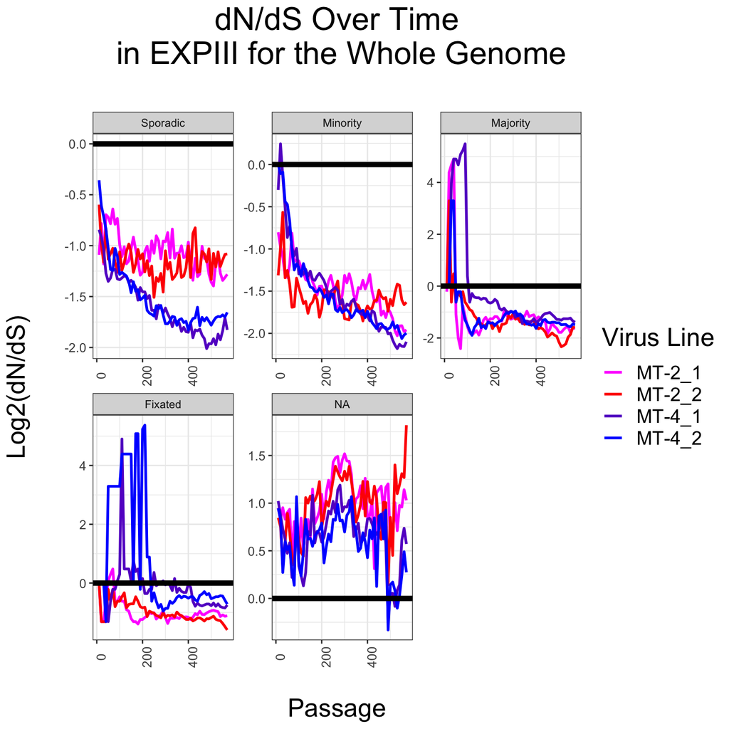

```r
# plot the difference eof synonymous and non-synonymous mutations
plt_type <- "plotly"

# get the synonymous and nonsynonymous likelihoods number for processing entire genome



syn_pos <- as.numeric(sum(gene_summary[,3]))
nonsyn_pos <- as.numeric(sum(gene_summary[,4]))

# iterate over experiments and plot

for (experiment in unique(variants$exp)){
    counts <- variants %>%
        mutate(mut_cat = factor(mut_cat, levels = mut_cat_factor)) %>%
        filter(exp == experiment) %>%
        mutate(effect_simplified = case_when(effect == "synonymous_variant" ~ "S", effect == "untranslated_region" ~ "U")) %>%
        mutate(effect_simplified = replace_na(effect_simplified, "N")) %>%
        filter(effect_simplified != "U") %>%
        mutate(effect_simplified = factor(effect_simplified, levels = c("N", "S"))) %>%
        group_by(exp_line, passage, mut_cat, effect_simplified, .drop=F) %>%
        count() %>%
        dplyr::rename(mut_count = n) %>%
        mutate(host_line = ifelse(exp_line %in% c("MT-4_1","MT-4_2"), "MT4", "MT2")) %>%
        mutate(exp_line = factor(exp_line, levels = exp_line_factor)) %>%
        mutate(effect_simplified = factor(effect_simplified, levels = c("N", "S"))) %>%
        mutate(host_line = factor(host_line, levels = c("MT2", "MT4")))

    counts_plt <-
        counts %>%
        spread(key = effect_simplified, mut_count) %>%
        mutate(S = case_when(S == 0 ~ S+0.01 , S !=0 ~ S)) %>%
        mutate(`dN/dS` = log((N/nonsyn_pos)/(S/syn_pos)))

    counts_plt$`dN/dS`[is.infinite(counts_plt$`dN/dS`) | is.nan(counts_plt$`dN/dS`)] <- 0


    fig <- counts_plt %>%
        ggplot(aes(x=passage, y = `dN/dS`, color = exp_line)) +
        geom_line(size=1) +
        facet_wrap(~mut_cat, scales = "free")+
        labs(x="\nPassage", y= "Log2(dN/dS)\n", color = "Virus Line", title = paste0("dN/dS Over Time\n in ", experiment, " for the Whole Genome", "\n"))+
        scale_color_manual(values = gg_var_list[[experiment]][["line_palette"]]) +
        scale_y_continuous() +
        geom_hline(yintercept = 0, color = "black", size = 2) +
        theme_bw() +
        theme(plot.title = element_text(size = gg_size_list[[plt_type]][["title.size"]], hjust = 0.5),
        axis.title = element_text(size = gg_size_list[[plt_type]][["axis.title.size"]]),
        axis.text.x = element_text(size = gg_size_list[[plt_type]][["axis.text.size"]], angle = 90),
        axis.text.y = element_text(size = gg_size_list[[plt_type]][["axis.text.size"]]),
        legend.title = element_text(size=gg_size_list[[plt_type]][["legend.title.size"]]),
        legend.text = element_text(size = gg_size_list[[plt_type]][["legend.text.size"]]))

    print(fig)

    # save pngs

    pdf(paste0("/Users/alimos313/Documents/studies/phd/hpc-research/genome-evo-proj/results/figs/pdf/jeffrey-barrick/dn_ds_", experiment, "_whole_genome", ".pdf")
    , width = 21, height = 21)
    print(fig)
    dev.off()

}
```

### 1.3.4 Whole Genome Statistical Significance

#### 1.3.4.1 positive vs purifying selection in each virus line

```r
syn_pos <- as.numeric(sum(gene_summary[,3]))
nonsyn_pos <- as.numeric(sum(gene_summary[,4]))


t_test_res_all <- data.frame()

for (experiment in unique(variants$exp)){
    counts <- variants %>%
        mutate(mut_cat = factor(mut_cat, levels = mut_cat_factor)) %>%
        filter(exp == experiment) %>%
        mutate(effect_simplified = case_when(effect == "synonymous_variant" ~ "S", effect == "untranslated_region" ~ "U")) %>%
        mutate(effect_simplified = replace_na(effect_simplified, "N")) %>%
        mutate(effect_simplified = factor(effect_simplified, levels = c("N", "S"))) %>%
        group_by(exp_line, passage, mut_cat, effect_simplified, .drop=F) %>%
        count() %>%
        dplyr::rename(mut_count = n) %>%
        mutate(host_line = ifelse(exp_line %in% c("MT-4_1","MT-4_2"), "MT4", "MT2")) %>%
        mutate(exp_line = factor(exp_line, levels = exp_line_factor)) %>%
        mutate(effect_simplified = factor(effect_simplified, levels = c("N", "S"))) %>%
        mutate(host_line = factor(host_line, levels = c("MT2", "MT4"))) %>%
        spread(key = effect_simplified, mut_count) %>%
        mutate(S = case_when(S == 0 ~ S+0.01 , S !=0 ~ S)) %>%
        mutate(`dN/dS` = log((N/nonsyn_pos)/(S/syn_pos)))


    counts$`dN/dS`[is.infinite(counts$`dN/dS`) | is.nan(counts$`dN/dS`)] <- 0

    for (mut_cat in mut_cat_factor){
        for (host_line in unique(counts$host_line)){
            dnds <- counts$`dN/dS`[counts$mut_cat == mut_cat & counts$host_line == host_line]

            t_test_res <- t.test(dnds, mu = 0, alternative = "two.sided")

            t_test_res_all <- rbind(t_test_res_all, c(experiment, host_line, mut_cat, round(mean(dnds),3), t_test_res$p.value))

    }
    }


}


colnames(t_test_res_all) <- c("exp", "host", "mut_cat", "mean(dN/dS)", "p-value")

datatable(t_test_res_all, filter = "bottom")
```

|  | exp | host | mut_cat | mean(dN/dS) | p-value |
| --- | --- | --- | --- | --- | --- |
| 1 | EXPIV | MT2 | Sporadic |  | 2.2863286334868e-16 |
| 2 | EXPIV | MT2 | Minority |  | 7.9932239027799e-09 |
| 3 | EXPIV | MT2 | Majority |  | 0.0021601710623546 |
| 4 | EXPIV | MT2 | Fixated |  | 2.04878474451712e-88 |
| 5 | EXPIII | MT2 | Sporadic |  | 1.03617039402119e-93 |
| 6 | EXPIII | MT4 | Sporadic |  | 2.79033385091366e-83 |
| 7 | EXPIII | MT2 | Minority |  | 6.05836548637921e-92 |
| 8 | EXPIII | MT4 | Minority |  | 4.82816528291667e-59 |
| 9 | EXPIII | MT2 | Majority |  | 2.46062525190302e-19 |
| 10 | EXPIII | MT4 | Majority |  | 2.15377811418846e-05 |

[output cut: 2 more lines]

#### 1.3.4.2 dN/dS level tests between each virus line group

```r
t_test_res_all <- data.frame()

counts <- variants %>%
    filter(exp != "EXPIII" | passage <= 510) %>%
    mutate(mut_cat = factor(mut_cat, levels = mut_cat_factor)) %>%
    mutate(effect_simplified = case_when(effect == "synonymous_variant" ~ "S", effect == "untranslated_region" ~ "U")) %>%
    mutate(effect_simplified = replace_na(effect_simplified, "N")) %>%
    mutate(effect_simplified = factor(effect_simplified, levels = c("N", "S"))) %>%
    group_by(exp_line, passage, mut_cat, effect_simplified, .drop=F) %>%
    count() %>%
    dplyr::rename(mut_count = n) %>%
    mutate(host_line = ifelse(exp_line %in% c("MT-4_1","MT-4_2"), "MT4", "MT2")) %>%
    mutate(exp_line = factor(exp_line, levels = exp_line_factor)) %>%
    mutate(effect_simplified = factor(effect_simplified, levels = c("N", "S"))) %>%
    mutate(host_line = factor(host_line, levels = c("MT2", "MT4"))) %>%
    spread(key = effect_simplified, mut_count) %>%
    mutate(S = case_when(S == 0 ~ S+0.01 , S !=0 ~ S)) %>%
    mutate(`dN/dS` = log((N/nonsyn_pos)/(S/syn_pos)))


counts$`dN/dS`[is.infinite(counts$`dN/dS`) | is.nan(counts$`dN/dS`)] <- 0

# counts_deformed[counts_deformed$exp_line == "III_MT-2" & counts_deformed$passage == 30 & counts_deformed$mut_cat == "Sporadic",]

counts_deformed <- counts %>%
            select(!c("N", "S")) %>%
            mutate(exp_line = case_when(exp_line %in% exp_line_factor[1:2] ~ "III_MT-2",
                                        exp_line %in% exp_line_factor[3:4] ~ "III_MT-4",
                                        exp_line %in% exp_line_factor[4:8] ~ "IV_MT-2")) %>%
            mutate(exp_line = factor(exp_line, levels = c("III_MT-2", "III_MT-4", "IV_MT-2"))) %>%
            select(-"host_line") %>%
            group_by(exp_line, passage, mut_cat) %>%
            summarise(`dN/dS mean` = mean(`dN/dS`)) %>%
            ungroup()

for (mut_cat in mut_cat_factor){

    dnds1 <- counts_deformed$`dN/dS mean`[counts_deformed$mut_cat == mut_cat & counts_deformed$exp_line == "III_MT-2"]
    dnds2 <- counts_deformed$`dN/dS mean`[counts_deformed$mut_cat == mut_cat & counts_deformed$exp_line == "III_MT-4"]
    dnds3 <- counts_deformed$`dN/dS mean`[counts_deformed$mut_cat == mut_cat & counts_deformed$exp_line == "IV_MT-2"]

    t_test_res1 <- t.test(dnds1, dnds2, paired = T, alternative = "two.sided")

    t_test_res_all <- rbind(t_test_res_all, c("III_MT-2 vs III_MT-4", mut_cat, round(mean(dnds1),3), round(mean(dnds2),3), t_test_res1$p.value))

    t_test_res2 <- t.test(dnds1, dnds3, paired = T, alternative = "two.sided")

    t_test_res_all <- rbind(t_test_res_all, c("III_MT-2 vs IV_MT-2", mut_cat, round(mean(dnds1),3), round(mean(dnds3),3), t_test_res2$p.value))

    t_test_res3 <- t.test(dnds2, dnds3, paired = T, alternative = "two.sided")

    t_test_res_all <- rbind(t_test_res_all, c("III_MT-4 vs IV_MT-2", mut_cat, round(mean(dnds2),3), round(mean(dnds3),3), t_test_res3$p.value))

}





colnames(t_test_res_all) <- c("comparison", "mut_cat", "mean(dN/dS) 1st", "mean(dN/dS) 2nd", "p-value")

datatable(t_test_res_all, filter = "bottom")
```

|  | comparison | mut_cat | mean(dN/dS) 1st | mean(dN/dS) 2nd | p-value |
| --- | --- | --- | --- | --- | --- |
| 1 | III_MT-2 vs III_MT-4 | Sporadic |  |  | 5.5091674285879e-17 |
| 2 | III_MT-2 vs IV_MT-2 | Sporadic |  |  | 2.16303368058902e-12 |
| 3 | III_MT-4 vs IV_MT-2 | Sporadic |  |  | 1.51164494246352e-16 |
| 4 | III_MT-2 vs III_MT-4 | Minority |  |  | 0.403399450845111 |
| 5 | III_MT-2 vs IV_MT-2 | Minority |  |  | 2.28222018129036e-11 |
| 6 | III_MT-4 vs IV_MT-2 | Minority |  |  | 1.42511882761374e-08 |
| 7 | III_MT-2 vs III_MT-4 | Majority |  |  | 0.00135764933739099 |
| 8 | III_MT-2 vs IV_MT-2 | Majority |  |  | 1.64242662965876e-05 |
| 9 | III_MT-4 vs IV_MT-2 | Majority |  |  | 0.197371103578271 |
| 10 | III_MT-2 vs III_MT-4 | Fixated |  |  | 3.22726025359772e-11 |

[output cut: 2 more lines]

Next step would be to profile the nonsynonymous mutations in terms of the amino acid changes that they cause and profile the synonymous mutations in terms of the codon usage changes (one can test this with permutation of mutations and simulating data)